# Semantic/Syntactic parsers for NL

# UCCA

## Universal Conceptual Cognitive Annotation

- Tutorials:
  - https://github.com/UniversalConceptualCognitiveAnnotation/tutorial
  - https://danielhers.github.io/uppsala_20191129.pdf
- Paper: https://aclanthology.org/P13-1023/
- corpora annotated in English, German and French, and ongoing annotation in Russian and Hebrew
- existing parsing work, including the findings of three recent shared tasks, in SemEval and CoNLL, that addressed UCCA parsing
- parser: https://github.com/danielhers/tupa

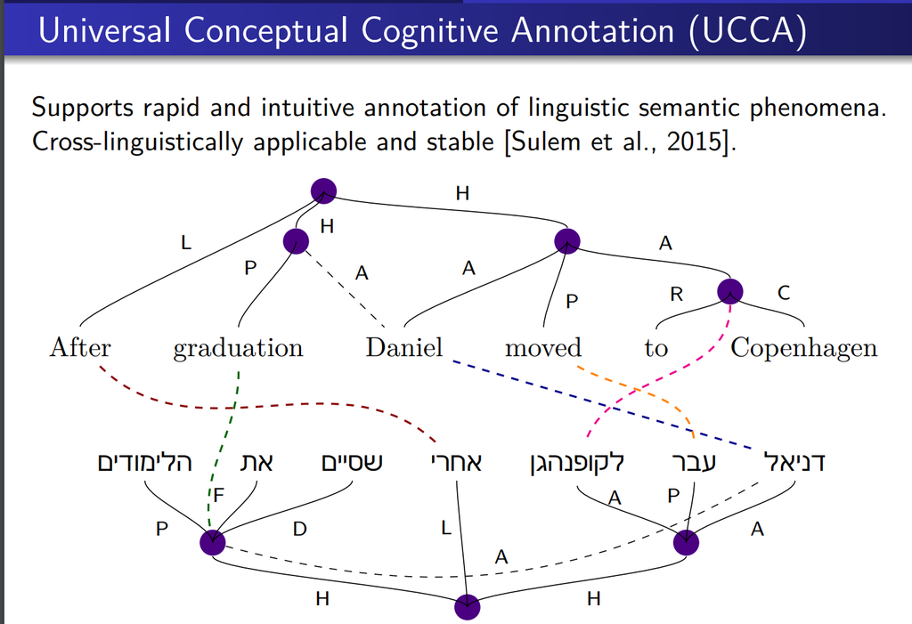

# AMR

*Einstein developed the Theory of Relativity.*

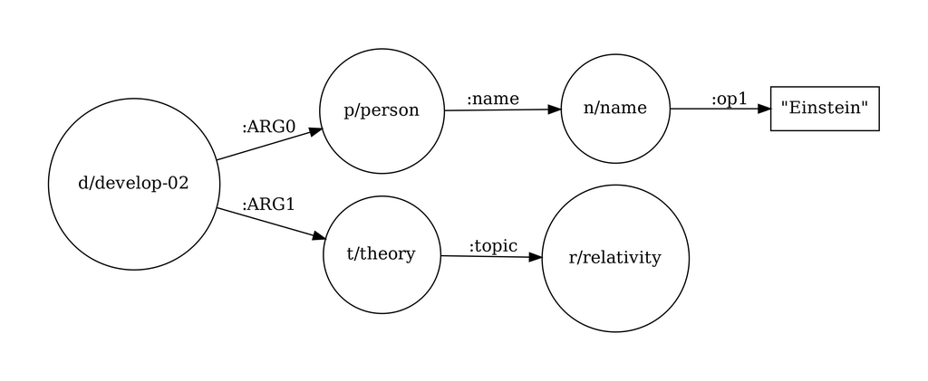

- Training data mainly for english
- Multilingual parser is available: https://arxiv.org/pdf/2109.15196.pdf
- The amrlib package is great for parsing to english: https://amrlib.readthedocs.io/en/latest/
  - easy to use
  - open source!

# Graphbrain (semantic hypergraph)

- A **Semantic Hypergraph** (SH) model
- **Graphbrain** combines symbolic and ML approaches
- The work was performed in the context of a computational social science (CSS) research team
- It is a formal language representation
- They define a parser with
  - modern NLP ML-based building blocks
  - and random forest classifier
  - simple search tree to parse NL to SH
- Great package, open source!
- Only for english, but actually not that hard to map to other languages

```python
from graphbrain.parsers import create_parser
from graphbrain import *
from graphbrain.notebook import *
from graphbrain.parsers import *

parser = create_parser(lang='en')

#Parse
graph = parser.parse('Einstein developed the Theory of Relativity.')
```

```python
blocks(graph["parses"][0]["main_edge"])
```

developed/P.so

einstein/C

of/B.ma

the/M

theory/C

relativity/C

# Universal Dependency Parsing

- https://universaldependencies.org/
- Lots of suppoert (70+ languages)
- Fairly cross-lingual
- Lots of good parsers:
  - Stanza: https://github.com/stanfordnlp/stanza
  - Spacy: https://spacy.io/
- Spacy is an industrial package
- Stanza is more of a research project
- But Stanza has better results

*Einstein developed the Theory of Relativity.*

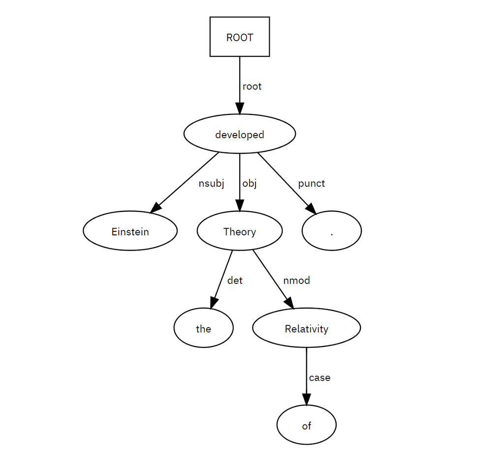

The spacy ecosystem is **rich**:

- Standard preprocessing tasks
- Segmentation, tokenization, morphology, lemmatization..
- Dependency parsing
- NER tagging: https://spacy.io/usage/linguistic-features/#named-entities
- Embedding vectors for words to calculate similarity: https://spacy.io/usage/linguistic-features/#vectors-similarity
- Good for basically all domains, e.g. scispacy: https://spacy.io/universe/project/scispacy

Lots of custom open-source pipelines:

- *ExtEnD*: Extractive Entity Disambiguation: https://github.com/SapienzaNLP/extend
- Few shot classification models: https://github.com/Pandora-Intelligence/classy-classification
- Few shot NER: https://github.com/Pandora-Intelligence/concise-concepts
- *Timexy*: A spaCy custom component that extracts and normalizes dates and other temporal expressions:
  - https://github.com/paulrinckens/timexy
- ClausIE: a novel, clause-based approach to open information extraction, which extracts relations and their arguments from natural language text!
  - https://github.com/mmxgn/spacy-clausie
- Handling negation: https://spacy.io/universe/project/negspacy
- Knowledge extraction: https://github.com/erre-quadro/spikex
- Link to DBPedia: https://github.com/MartinoMensio/spacy-dbpedia-spotlight
- Link to Wordnet: https://spacy.io/universe/project/spacy-wordnet

Spacy also have a rule-based matcher: https://spacy.io/usage/rule-based-matching

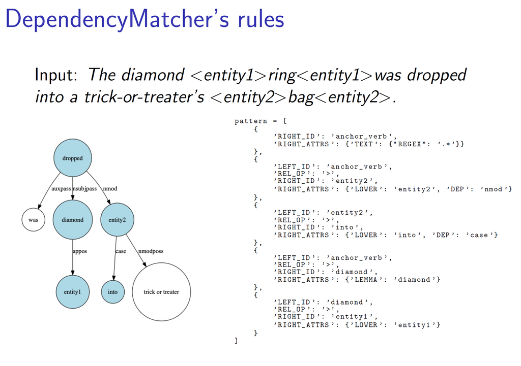

# 4lang

- Our own format
- Built from UD using regular grammars
- Mapping UD edges to three types
- Parser: https://github.com/recski/tuw-nlp
- For English and German currently

Edge types

- 0-edges
  - unary predication (`dog` →0 `bark`)
  - attribution (`dog` → 0 `four-legged`)
  - hypernymy, or the `IS_A` relation (`dog` → 0 `mammal`).
- 1- and 2-edges
  - transitive verbs (`cat` 1 ← `CATCH` → 2 `mouse`)
  - a small set of binary primitives (`tree` 1 ← `HAS` → 2 `branch`).

```python
from tuw_nlp.grammar.text_to_4lang import TextTo4lang
from tuw_nlp.graph.utils import graph_to_pn
```

```python
tfl = TextTo4lang("en", "en_nlp_cache")

fl_graphs = list(tfl("Einstein developed the Theory of Relativity."))
```

```python
from tuw_nlp.graph.fourlang import FourLang
from graphviz import Source

Source(FourLang(fl_graphs[0], None).to_dot())
```

[figure not shown]

```python
tfl.lexicon.get_definition("develop")
```

```
'To change with a specific direction, progress.'
```

```python
fl_graphs = list(tfl("Einstein developed the Theory of Relativity.", depth=1, substitute=False, expand_set={"develop"}))
```

```python
Source(FourLang(fl_graphs[0], None).to_dot())
```

[figure not shown]

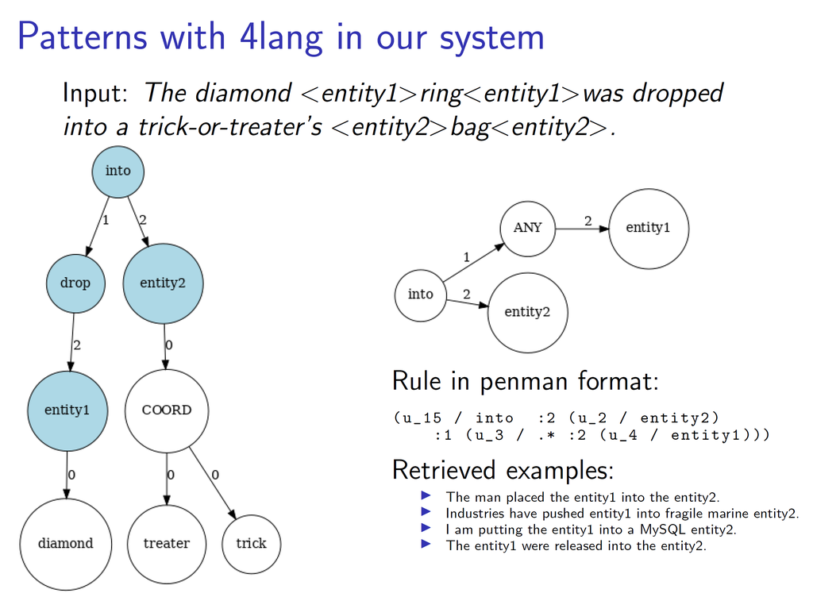

# Useful tools

## Holmes-extractor

- https://github.com/msg-systems/holmes-extractor
- Holmes is a Python 3 library (tested with version 3.9.5) running on top of spaCy (tested with version 3.1.2) that supports a number of use cases involving information extraction from English and German texts.
- Allows search like:
  - holmes_manager.register_search_phrase('An ENTITYPERSON goes into town')

*English:*

| Identifier | Meaning |
| --- | --- |
| ENTITYNOUN | Any noun phrase. |
| ENTITYPERSON | People, including fictional. |
| ENTITYNORP | Nationalities or religious or political groups. |
| ENTITYFAC | Buildings, airports, highways, bridges, etc. |
| ENTITYORG | Companies, agencies, institutions, etc. |
| ENTITYGPE | Countries, cities, states. |
| ENTITYLOC | Non-GPE locations, mountain ranges, bodies of water. |
| ENTITYPRODUCT | Objects, vehicles, foods, etc. (Not services.) |
| ENTITYEVENT | Named hurricanes, battles, wars, sports events, etc. |
| ENTITYWORK_OF_ART | Titles of books, songs, etc. |
| ENTITYLAW | Named documents made into laws. |
| ENTITYLANGUAGE | Any named language. |
| ENTITYDATE | Absolute or relative dates or periods. |
| ENTITYTIME | Times smaller than a day. |
| ENTITYPERCENT | Percentage, including "%". |
| ENTITYMONEY | Monetary values, including unit. |
| ENTITYQUANTITY | Measurements, as of weight or distance. |
| ENTITYORDINAL | "first", "second", etc. |
| ENTITYCARDINAL | Numerals that do not fall under another type. |

*German:*

| Identifier | Meaning |
| --- | --- |
| ENTITYNOUN | Any noun phrase. |
| ENTITYPER | Named person or family. |
| ENTITYLOC | Name of politically or geographically defined location (cities, provinces, countries, international regions, bodies of water, mountains). |
| ENTITYORG | Named corporate, governmental, or other organizational entity. |
| ENTITYMISC | Miscellaneous entities, e.g. events, nationalities, products or works of art. |

# FRED

- http://wit.istc.cnr.it/stlab-tools/fred/
- Didn't find tool available, only rest api
- You need API key: https://docs.google.com/forms/d/e/1FAIpQLScPO_xL_F6yw9Cf9p5rNyKpOZDsHXY1fs6C0zo8jv4NDK_EvQ/viewform
- Its actually max 5 request / min

# Evaluation

## Parsers

- UD parsers (spacy, stanza)
- AMR parsers (amrlib, ...)
- GraphBrain (as a knowledge base, as a semantic hypergraph, as a pattern language)
- UCCA (parsers, what it is good for)

## Lexical resources

- Babelnet
- Conceptnet
- Wordnet
- VerbAtlas
- WiktData, Wiktionary
- Maybe other ontologies

## Criteria

- Availability
- Languages
- Is it actively developed
- Resources
- Adaptability
- Knowledge base
  - How can we link graphs into lexical resources (e.g. conceptnet)